# GO Enrichment and Visualization

# 3. KEGG pathway enrichment

the function, that execute a KEGG enrichment, needs entez ids of the genes so the first step is a conversion from hgnc symbols to entrez ids the conversion is not 100% successful, since some symbols do not have an entrez ids

```r
convert_ID <- function(genelist){
  ids<-bitr(genelist$genes, fromType = "ALIAS", toType = "ENTREZID", OrgDb= org.Hs.eg.db)

  # only one entrrez id per hgnc symbol
  dedup_ids = ids[!duplicated(ids[c("ALIAS")]),]
  df = right_join(genelist, dedup_ids, by= c("genes" = "ALIAS"))

  # delete hgnc symbols that have the same entrez ids
  same.entrez.ids <- df[duplicated(df$ENTREZID),]$ENTREZID
  df<- filter(df, !(ENTREZID %in% same.entrez.ids))

  gene.list.ID <- (df$log2FoldChange)
  # Name vector with ENTREZ ids
  names(gene.list.ID) <- as.character(df$ENTREZID)
  # sort the list in decreasing order (required for clusterProfiler)
  gene.list.ID = sort(gene.list.ID, decreasing = TRUE)
  return(gene.list.ID)
}

KEGG_upregulated_list <- convert_ID(upregulated)
```

```
Warnung in bitr(genelist$genes, fromType = "ALIAS", toType = "ENTREZID",
  3.02% of input gene IDs are fail to map...
```

```r
KEGG_downregulated_list <- convert_ID(downregulated)
```

```
Warnung in bitr(genelist$genes, fromType = "ALIAS", toType = "ENTREZID",
  2.97% of input gene IDs are fail to map...
```

now we can run the enrichment

```r
up_kk <- gseKEGG(geneList = KEGG_upregulated_list,
               organism     = "hsa",
               nPermSimple   = 10000,
               minGSSize    = 1,
               maxGSSize    = 800,
               pvalueCutoff = 0.05,
               #pAdjustMethod = "BH",
               keyType       = "ncbi-geneid")
```

```
preparing geneSet collections...
GSEA analysis...
leading edge analysis...
done...
```

unfortunately there was only one pathway enriched, that has nothing to do with AD

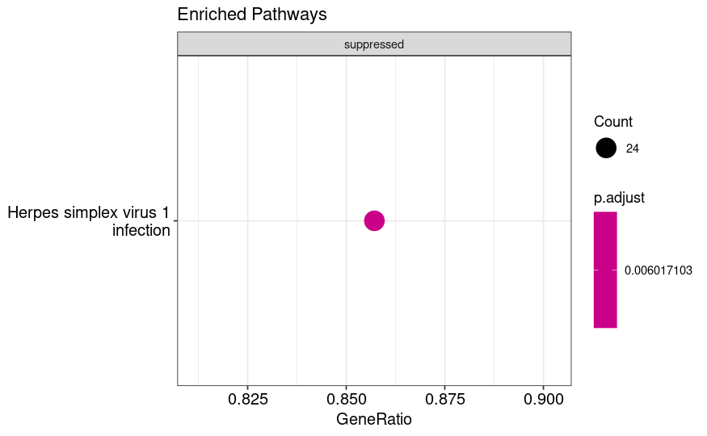

```r
dotplot(up_kk, showCategory = 10, title = "Enriched Pathways" , split=".sign") + facet_grid(.~.sign)
```

# 4. Reactome Pathway Enrichment

Since the KEGG enrichment was not successful, we now using the pathways annotated by the Reactome pathway The online DAVID enrichment already discovered already the pathway “The citric acid (TCA) cycle and respiratory electron transport” The malfunction of TCA and energy production in the mitochondria is well documented in AD, that’s why we choose this one to visualize.

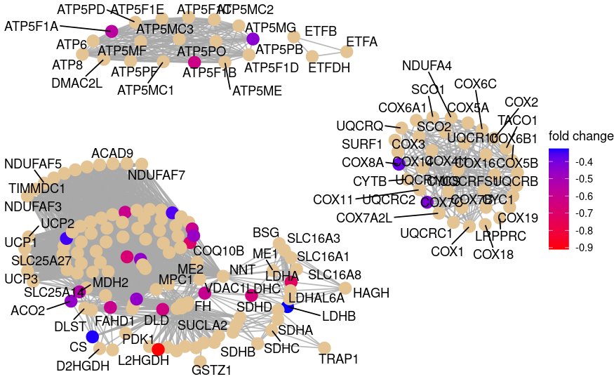

```r
library(ReactomePA)
down.pathways <- enrichPathway(names(KEGG_downregulated_list), organism = "human", pvalueCutoff=0.05, pAdjustMethod = "BH")
up.pathways <-  enrichPathway(names(KEGG_upregulated_list), organism = "human", pvalueCutoff=0.05, pAdjustMethod = "BH")

# downregulated genes are colored
viewPathway("The citric acid (TCA) cycle and respiratory electron transport", foldChange = KEGG_downregulated_list, readable = TRUE)
```

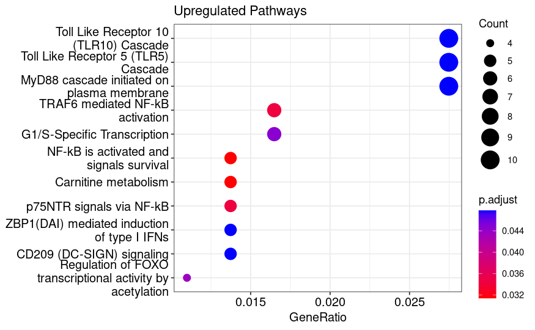

```r
# transcription related pathways are upregulated as well as neuronal specific signal pathways
dotplot(up.pathways, showCategory = 20, title = "Upregulated Pathways")
```

```r
NA
NA
```